# Fantasy Football Analysis

By: Andrew Yang, Megan Yu, and Frank Deegbe

## Motivation

For decades fantasy football has dominated the landscape of sports betting by striking a perfect balance between strategy, competition, and luck. It is a online game where participants can create their own football teams by selecting real life NFL players. Each participant, known as a manager, can draft these players from across the league, who will then earn points based on their real world game statistics every week.

Although managers can continue to make changes to their team after the season starts, one of the most pivotal moments of the game is the draft, where players generally select 16 players onto their initial roster in a snake draft. Over the years, many different strategies for drafting have emerged, such as waiting on a quarterback (QB), drafting runningbacks (RB) and wide receivers (WR) in the earlier rounds, or waiting on a runningback to ensure the top talent in other positions.

Having a good draft has significant implications for the season overall. A manager is able to accept a player drafted late to underproduce, as the draft capital for the player is not very high and could easily be cut for free agents. However, if a player drafted within the early rounds (Rounds 1-6) underproduces, it causes significant turmoil since the manager spent a high capital for the player and would not get equivalent return value for trading the player. On the other hand, drafting a sleeper player in the later rounds that massively overproduces becomes a valuable asset and is a critical piece of championship teams, as the overall strength of a manager's team is improved with the same draft cost in relation to the other teams.

A good draft strategy thus looks to minimize the risk of players within the early rounds, while is also good at finding the specific sleepers in the later rounds.

Additional resources can be found here

- [https://www.espn.com/fantasy/football/story/_/id/34389554/fantasy-football-beginners-how-play-fantasy-football-2022]
- [https://www.espn.com/fantasy/football/story/_/id/39266124/2024-fantasy-football-draft-rankings-strategy-2023-takeaways]
- [https://www.si.com/fantasy/top-10-fantasy-football-rookies-nfl-draft-2024-01hxs07j8ck3]
- [https://www.rotoballer.com/rb-dead-zone-what-is-it-and-do-you-really-need-to-avoid-it/1192614]
- [https://draftwizard.fantasypros.com/football/mock-draft-simulator/settings/]
- [https://www.rotoballer.com/fantasy-football-teams-in-a-vacuum/1164424]

Based on the resources above, we have found the following questions to answer in order to determine the players strategy at a particular round.

- Does the runningback dead zone exist?
- Is drafting a quarterback or tight end within the first 3 rounds worth the investment?
- Which position has the most amount of sleepers?
- Can we predict how well a quarterback will do based on their volume metrics?

The objective of this project is to use statistics and data science to answer the questions above. We hope that through this tutorial, the reader will gain a better understanding of the various draft strategies used in fantasy football as well as better understand how concepts within data science can more accurately model the performance of NFL players.

## Procedure

We will be using the following datasets

- [NFL-Season-DATA](https://github.com/hvpkod/NFL-Data) dataset.
- [Average-Draft-Positions](https://www.fantasypros.com/nfl/adp/ppr-overall.php) dataset.

Each dataset contains statistics of NFL players dating back to 2015, with the first dataset detailing their in season performance and the second dataset containing their average draft positions on various fantasy football platforms.

We will track the following seasons: 2020, 2021, 2022, 2023, combining the two datasets together for each season.

We will then create 4 different data frames represented for each season. If we need to measure a specific player, we will aggregate the 4 different dataframes together, and we would exclude players who have retired within the time frame (2020-2023), meaning 1st, 2nd, and 3rd year players would be included.

# Part 1: Data Collection

### A. Get NFL-Data

About our first data set:

- Our data is extracted from Fantasy.NFL.com divided by season and player position, along with weekly numbers.
- The extract goes back to the 2015 season as that is the first available season with a full dataset for all positions.
- Point total and player-ranks are specific for the MML leagues point system but all outer data are raw and can be used for other calculations and simulations.
- All data are available in comma-separated csv files or row-divided JSON.

During this project, we will be using Python language, and we use tools such as [VS Code](https://code.visualstudio.com/) and [Jupiter Notebook](https://jupyter.org/) to develop this project.

Just like any other Python project, we need to import some libraries. Here are some of the libraries we will be using throughout this tutorial.

**Imports**

```python
# !pip install numpy pandas seaborn matplotlib folium scipy scikit-learn tensorflow
import os
import folium
import warnings
import datetime
import numpy as np
import pandas as pd
import seaborn as sns
import matplotlib.pyplot as plt
from scipy import stats
import math
# this is just an example idk if we gonna need em
```

From NFL-Data git repo, we get data for running backs, wide receivers, tight ends, and quarterbacks for years 2015-2023. We read each year into a separate dataframe. We consolidate 4 lists of dataframes, one for each position.

#### Running Backs

Displayed below the code are the top five running backs of 2023, as well as their statistics. Some positive contributions (Passing yards, Passing touchdowns, Rushing yards, Rushing touchdowns, Receptions, Receiving yards, Receiving touchdowns...) are input into a formula which outputs their "Total Points" - the final column. We will use Total Points to rank players to analyze their performance.

```python
# the years we'd like to consider
years = ["2020", "2021", "2022", "2023"]
# array of dataframes containing RB data for years 2020-2023
rb_dfs = []
for year in years:
    # read the github url to raw csv data into a pandas dataframe
    rb_url = "https://raw.githubusercontent.com/hvpkod/NFL-Data/main/NFL-data-Players/"+ year +"/RB_season.csv"
    rb_df = pd.read_csv(rb_url)
    # only keep top 50 elements
    rb_df = rb_df.head(50)
    # remove jr
    rb_df['PlayerName'] = rb_df['PlayerName'].str.replace(r'\s+(Jr|Sr)\.?$', '', regex=True)
    # add df for current year onto list of all dataframes
    rb_dfs.append(rb_df)

rb_dfs[-1].head()
```

|  | PlayerName | PlayerId | Pos | Team | PassingYDS | PassingTD | PassingInt | RushingYDS | RushingTD | ReceivingRec | ... | TouchReceptions | Touches | TargetsReceptions | Targets | ReceptionPercentage | RzTarget | RzTouch | RzG2G | Rank | TotalPoints |
| --- | --- | --- | --- | --- | --- | --- | --- | --- | --- | --- | --- | --- | --- | --- | --- | --- | --- | --- | --- | --- | --- |
| 0 | Christian McCaffrey | 2557997 | RB | SF | NaN | NaN | NaN | 1459.0 | 14.0 | 67.0 | ... | 67.0 | 339.0 | 67.0 | 83.0 | 81.0 | 16.0 | 75.0 | 39.0 | 1 | 359.80 |
| 1 | Travis Etienne | 2566157 | RB | JAX | NaN | NaN | NaN | 1008.0 | 11.0 | 58.0 | ... | 58.0 | 325.0 | 58.0 | 73.0 | 79.0 | 2.0 | 39.0 | 15.0 | 2 | 256.40 |
| 2 | Breece Hall | 2568030 | RB | NYJ | NaN | NaN | NaN | 994.0 | 5.0 | 76.0 | ... | 76.0 | 299.0 | 76.0 | 95.0 | 80.0 | 5.0 | 25.0 | 17.0 | 3 | 254.50 |
| 3 | Raheem Mostert | 2553728 | RB | MIA | NaN | NaN | NaN | 1012.0 | 18.0 | 25.0 | ... | 25.0 | 234.0 | 25.0 | 32.0 | 78.0 | 5.0 | 50.0 | 32.0 | 4 | 250.17 |
| 4 | Joe Mixon | 2557976 | RB | CIN | NaN | NaN | NaN | 1034.0 | 9.0 | 52.0 | ... | 52.0 | 309.0 | 52.0 | 64.0 | 81.0 | 13.0 | 67.0 | 42.0 | 5 | 241.00 |

5 rows × 28 columns

In the running backs dataframe, many of the players listed toward the bottom of the rankings have 0 total points. This is because they did not play. We do not need to consider the lowest scoring players in each year. Thus, we will only consider the top 50 performers of each year for running backs and wide receivers. For quarterbacks and tight ends, we will only refer to the top 32 performers for each year.

#### Quarter backs

We only consider the top 32. The top 5 players are displayed below.

```python
# array of dataframes containing QB data for years 2020-2023
qb_dfs = []
for year in years:
    qb_url = "https://raw.githubusercontent.com/hvpkod/NFL-Data/main/NFL-data-Players/"+ year +"/QB_season.csv"
    qb_df = pd.read_csv(qb_url)
    qb_df = qb_df.head(32)
    # remove jr
    qb_df['PlayerName'] = qb_df['PlayerName'].str.replace(r'\s+(Jr|Sr)\.?$', '', regex=True)
    qb_dfs.append(qb_df)

qb_dfs[-1].head()
```

|  | PlayerName | PlayerId | Pos | Team | PassingYDS | PassingTD | PassingInt | RushingYDS | RushingTD | ReceivingRec | ... | TouchReceptions | Touches | TargetsReceptions | Targets | ReceptionPercentage | RzTarget | RzTouch | RzG2G | Rank | TotalPoints |
| --- | --- | --- | --- | --- | --- | --- | --- | --- | --- | --- | --- | --- | --- | --- | --- | --- | --- | --- | --- | --- | --- |
| 0 | Josh Allen | 2560955 | QB | BUF | 4306.0 | 29.0 | 18.0 | 524.0 | 15.0 | NaN | ... | NaN | 111.0 | NaN | NaN | NaN | NaN | 35.0 | 18.0 | 1 | 387.51 |
| 1 | Jalen Hurts | 2564832 | QB | PHI | 3858.0 | 23.0 | 15.0 | 605.0 | 15.0 | NaN | ... | NaN | 157.0 | NaN | NaN | NaN | NaN | 43.0 | 26.0 | 2 | 354.22 |
| 2 | Dak Prescott | 2555260 | QB | DAL | 4516.0 | 36.0 | 9.0 | 242.0 | 2.0 | NaN | ... | NaN | 55.0 | NaN | NaN | NaN | NaN | 13.0 | 5.0 | 3 | 341.31 |
| 3 | Lamar Jackson | 2560757 | QB | BAL | 3678.0 | 24.0 | 7.0 | 821.0 | 5.0 | NaN | ... | NaN | 148.0 | NaN | NaN | NaN | NaN | 30.0 | 10.0 | 4 | 325.59 |
| 4 | Jordan Love | 2564007 | QB | GB | 4159.0 | 32.0 | 11.0 | 247.0 | 4.0 | NaN | ... | NaN | 50.0 | NaN | NaN | NaN | NaN | 9.0 | 5.0 | 5 | 309.86 |

5 rows × 28 columns

#### Wide receivers

We only consider the top 50. The top 5 players are displayed below.

```python
# array of dataframes containing WR data for years 2020-2023
wr_dfs = []
for year in years:
    wr_url = "https://raw.githubusercontent.com/hvpkod/NFL-Data/main/NFL-data-Players/"+ year +"/WR_season.csv"
    wr_df = pd.read_csv(wr_url)
    wr_df = wr_df.head(50)
    # remove jr
    wr_df['PlayerName'] = wr_df['PlayerName'].str.replace(r'\s+(Jr|Sr)\.?$', '', regex=True)
    wr_dfs.append(wr_df)

wr_dfs[-1].head()
```

|  | PlayerName | PlayerId | Pos | Team | PassingYDS | PassingTD | PassingInt | RushingYDS | RushingTD | ReceivingRec | ... | TouchReceptions | Touches | TargetsReceptions | Targets | ReceptionPercentage | RzTarget | RzTouch | RzG2G | Rank | TotalPoints |
| --- | --- | --- | --- | --- | --- | --- | --- | --- | --- | --- | --- | --- | --- | --- | --- | --- | --- | --- | --- | --- | --- |
| 0 | CeeDee Lamb | 2563848 | WR | DAL | NaN | NaN | NaN | 113.0 | 2.0 | 135.0 | ... | 135.0 | 149.0 | 135.0 | 181.0 | 75.0 | 31.0 | 20.0 | 22.0 | 1 | 336.2 |
| 1 | Tyreek Hill | 2556214 | WR | MIA | NaN | NaN | NaN | 15.0 | NaN | 119.0 | ... | 119.0 | 125.0 | 119.0 | 171.0 | 70.0 | 23.0 | 14.0 | 14.0 | 2 | 324.4 |
| 2 | Amon-Ra St. Brown | 2566073 | WR | DET | NaN | NaN | NaN | 24.0 | NaN | 119.0 | ... | 119.0 | 123.0 | 119.0 | 164.0 | 73.0 | 23.0 | 16.0 | 11.0 | 3 | 279.1 |
| 3 | DJ Moore | 2560813 | WR | CHI | NaN | NaN | NaN | 21.0 | 1.0 | 96.0 | ... | 96.0 | 100.0 | 96.0 | 136.0 | 71.0 | 11.0 | 8.0 | 7.0 | 4 | 246.5 |
| 4 | Puka Nacua | 2570026 | WR | LA | NaN | NaN | NaN | 89.0 | NaN | 105.0 | ... | 105.0 | 117.0 | 105.0 | 160.0 | 66.0 | 16.0 | 11.0 | 11.0 | 5 | 246.5 |

5 rows × 28 columns

#### Tight ends

We only consider the top 32. The top 5 players are displayed below.

```python
# array of dataframes containing TE data for years 2020-2023
te_dfs = []
for year in years:
    te_url = "https://raw.githubusercontent.com/hvpkod/NFL-Data/main/NFL-data-Players/"+ year +"/TE_season.csv"
    te_df = pd.read_csv(te_url)
    te_df = te_df.head(32)
    # remove jr
    te_df['PlayerName'] = te_df['PlayerName'].str.replace(r'\s+(Jr|Sr)\.?$', '', regex=True)
    te_dfs.append(te_df)

te_dfs[-1].head()
```

|  | PlayerName | PlayerId | Pos | Team | PassingYDS | PassingTD | PassingInt | RushingYDS | RushingTD | ReceivingRec | ... | TouchReceptions | Touches | TargetsReceptions | Targets | ReceptionPercentage | RzTarget | RzTouch | RzG2G | Rank | TotalPoints |
| --- | --- | --- | --- | --- | --- | --- | --- | --- | --- | --- | --- | --- | --- | --- | --- | --- | --- | --- | --- | --- | --- |
| 0 | Sam LaPorta | 2569726 | TE | DET | NaN | NaN | NaN | 4.0 | NaN | 86.0 | ... | 86.0 | 87.0 | 86.0 | 120.0 | 72.0 | 15.0 | 11.0 | 15.0 | 1 | 199.6 |
| 1 | Evan Engram | 2557858 | TE | JAX | NaN | NaN | NaN | NaN | NaN | 114.0 | ... | 114.0 | 114.0 | 114.0 | 143.0 | 80.0 | 9.0 | 6.0 | 4.0 | 2 | 176.8 |
| 2 | Travis Kelce | 2540258 | TE | KC | NaN | NaN | NaN | NaN | NaN | 93.0 | ... | 93.0 | 93.0 | 93.0 | 121.0 | 77.0 | 19.0 | 13.0 | 12.0 | 3 | 174.4 |
| 3 | T.J. Hockenson | 2562378 | TE | MIN | NaN | NaN | NaN | NaN | NaN | 95.0 | ... | 95.0 | 95.0 | 95.0 | 127.0 | 75.0 | 9.0 | 6.0 | 9.0 | 4 | 173.0 |
| 4 | George Kittle | 2558266 | TE | SF | NaN | NaN | NaN | 2.0 | NaN | 65.0 | ... | 65.0 | 66.0 | 65.0 | 90.0 | 72.0 | 12.0 | 8.0 | 6.0 | 5 | 172.2 |

5 rows × 28 columns

### B. Get Average Draft Positions (ADP) Rankings Data

Now, onto our second data set. From fantasypros website, we get the Average Draft Position (ADP) for all players in years 2020-2023.

We drop all the irrelevant columns to only keep name (Player), position (POS), and average ADP (AVG).

Some players names have Jr, Jr., Sr, or Sr. at the end. Sometimes one database will include the suffix while another will not. Moreover, the suffix may or may not have a period. This poses a problem because we need to merge databases together by name. Since there is so much variability, we decided to remove these suffixes from all names if it exists. We do so with regex.

The first five rows of the 2023 ADP rankings are displayed below as an example.

```python
# array of dataframes containing Overall ADP data for years 2020-2023
adp_overall_dfs = []

# we only need the AVG ADP column, so we can drop all others
columns_to_drop = ['Rank', 'Team', 'Bye', 'ESPN', 'Sleeper', 'NFL', 'RTSports', 'FFC']

for year in years:
    # read csv data from csv files in our Data folder
    path = "./Data/FantasyPros_" + year + "_Overall_ADP_Rankings.csv"
    df = pd.read_csv(path)
    df.drop(columns=columns_to_drop, axis=1, inplace=True)
    # remove jr
    df['Player'] = df['Player'].str.replace(r'\s+(Jr|Sr)\.?$', '', regex=True)
    adp_overall_dfs.append(df)

    # Fill N/A values with an empty string
    df['POS'] = df['POS'].fillna('')

adp_overall_dfs[-1].head()
```

|  | Player | POS | AVG |
| --- | --- | --- | --- |
| 0 | Christian McCaffrey | RB1 | 1.8 |
| 1 | Austin Ekeler | RB2 | 4.3 |
| 2 | Ja'Marr Chase | WR1 | 4.5 |
| 3 | Tyreek Hill | WR2 | 4.8 |
| 4 | Travis Kelce | TE1 | 6.5 |

We will now separate out the overall ADP data to create separate dataframes for the runningbacks, wide receivers, quarterbacks, and tight ends.

```python
# Function to filter WRs from each dataframe
# pos_tag may be WR, RB, QB, or TE
def filter_position(df, pos_tag):
    return df[df['POS'].str.startswith(pos_tag)]
```

```python
# Create a list of dataframes containing only WRs for each year
adp_wrs_dfs = [filter_position(df, 'WR') for df in adp_overall_dfs]

# Example: Display the head of the WR dataframe for the last year
adp_wrs_dfs[-1].head()
```

|  | Player | POS | AVG |
| --- | --- | --- | --- |
| 2 | Ja'Marr Chase | WR1 | 4.5 |
| 3 | Tyreek Hill | WR2 | 4.8 |
| 5 | Stefon Diggs | WR3 | 8.8 |
| 6 | Justin Jefferson | WR4 | 9.3 |
| 8 | A.J. Brown | WR5 | 11.8 |

```python
# Create a list of dataframes containing only RBs for each year
adp_rbs_dfs = [filter_position(df, 'RB') for df in adp_overall_dfs]

# Example: Display the head of the RB dataframe for the last year
adp_rbs_dfs[-1].head()
```

|  | Player | POS | AVG |
| --- | --- | --- | --- |
| 0 | Christian McCaffrey | RB1 | 1.8 |
| 1 | Austin Ekeler | RB2 | 4.3 |
| 7 | Bijan Robinson | RB3 | 10.3 |
| 9 | Saquon Barkley | RB4 | 12.0 |
| 11 | Tony Pollard | RB5 | 13.5 |

```python
# Create a list of dataframes containing only QBs for each year
adp_qbs_dfs = [filter_position(df, 'QB') for df in adp_overall_dfs]

# Example: Display the head of the QB dataframe for the last year
adp_qbs_dfs[-1].head()
```

|  | Player | POS | AVG |
| --- | --- | --- | --- |
| 13 | Patrick Mahomes II | QB1 | 15.3 |
| 17 | Jalen Hurts | QB2 | 20.3 |
| 20 | Josh Allen | QB3 | 22.3 |
| 35 | Lamar Jackson | QB4 | 38.0 |
| 37 | Justin Herbert | QB5 | 43.8 |

```python
# Create a list of dataframes containing only TEs for each year
adp_tes_dfs = [filter_position(df, 'TE') for df in adp_overall_dfs]

# Example: Display the head of the TE dataframe for the last year
adp_tes_dfs[-1].head()
```

|  | Player | POS | AVG |
| --- | --- | --- | --- |
| 4 | Travis Kelce | TE1 | 6.5 |
| 24 | Mark Andrews | TE2 | 32.3 |
| 34 | T.J. Hockenson | TE3 | 37.8 |
| 45 | George Kittle | TE4 | 52.3 |
| 57 | Darren Waller | TE5 | 64.8 |

# Part 2: Data Processing

We'll merge the NFL-Data and ADP data dataframes together by player name. We do a left merge, essentially adding ADP ranking to our dataframe of all NFL-Data. Once it's merged together, we drop the repeated Player name column, since it's now in there twice.

Furthermore, we will add one more column to the dataset, which contains the average round in which the running backs are drafted in. We calculate this with by dividing the average draft position *(ADP)* by 12 (the standard league size). This will come in useful during our exploratory data analysis.

Here is a function that completes this merge and adds the new column:

```python
# params: list of nfl data dfs, list of adp data dfs
# returns merged df
def merge_dfs(nfl_df_lst, adp_df_list):
    # iterate through years
    for i in range(4):
        nfl_df_lst[i] = pd.merge(nfl_df_lst[i], adp_df_list[i], how="left", left_on="PlayerName", right_on="Player")
        # drop repeat player name column
        nfl_df_lst[i].drop(columns=['Player'], axis=1, inplace=True)
        # we take the floor to have a whole number
        nfl_df_lst[i]['RoundDrafted'] = np.floor(nfl_df_lst[i]['AVG'] / 12) + 1

    return nfl_df_lst
```

We'll first consider the Running Backs. We will update the rb_dfs with the merged version rb_dfs and adp_rbs_dfs combined.

We display the top five lines of RB 2023 as an example. As you can see, there is an added AVG and RoundDrafted columns.

```python
rb_dfs = merge_dfs(rb_dfs, adp_rbs_dfs)

rb_dfs[-1].head()
```

|  | PlayerName | PlayerId | Pos | Team | PassingYDS | PassingTD | PassingInt | RushingYDS | RushingTD | ReceivingRec | ... | Targets | ReceptionPercentage | RzTarget | RzTouch | RzG2G | Rank | TotalPoints | POS | AVG | RoundDrafted |
| --- | --- | --- | --- | --- | --- | --- | --- | --- | --- | --- | --- | --- | --- | --- | --- | --- | --- | --- | --- | --- | --- |
| 0 | Christian McCaffrey | 2557997 | RB | SF | NaN | NaN | NaN | 1459.0 | 14.0 | 67.0 | ... | 83.0 | 81.0 | 16.0 | 75.0 | 39.0 | 1 | 359.80 | RB1 | 1.8 | 1.0 |
| 1 | Travis Etienne | 2566157 | RB | JAX | NaN | NaN | NaN | 1008.0 | 11.0 | 58.0 | ... | 73.0 | 79.0 | 2.0 | 39.0 | 15.0 | 2 | 256.40 | RB8 | 23.5 | 2.0 |
| 2 | Breece Hall | 2568030 | RB | NYJ | NaN | NaN | NaN | 994.0 | 5.0 | 76.0 | ... | 95.0 | 80.0 | 5.0 | 25.0 | 17.0 | 3 | 254.50 | RB9 | 34.0 | 3.0 |
| 3 | Raheem Mostert | 2553728 | RB | MIA | NaN | NaN | NaN | 1012.0 | 18.0 | 25.0 | ... | 32.0 | 78.0 | 5.0 | 50.0 | 32.0 | 4 | 250.17 | RB35 | 114.8 | 10.0 |
| 4 | Joe Mixon | 2557976 | RB | CIN | NaN | NaN | NaN | 1034.0 | 9.0 | 52.0 | ... | 64.0 | 81.0 | 13.0 | 67.0 | 42.0 | 5 | 241.00 | RB12 | 36.0 | 4.0 |

5 rows × 31 columns

Now, we'll do the same merge for the QBs, TEs, and WRs.

```python
qb_dfs = merge_dfs(qb_dfs, adp_qbs_dfs)

te_dfs = merge_dfs(te_dfs, adp_tes_dfs)

wr_dfs = merge_dfs(wr_dfs, adp_wrs_dfs)
```

# Part 3: Exploratory Analysis & Data Visualization

### Total points vs Round drafted, all positions, all years

We will plot the ADP (avg draft position) of players across positions against their total points to see if people are actually drafting the best players first. Our first plot will have data from all four years for all positions.

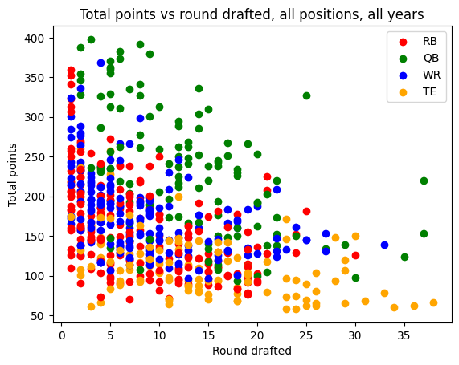

```python
plt.figure()
plt.title('Total points vs round drafted, all positions, all years')
plt.xlabel('Round drafted')
plt.ylabel('Total points')

# for each year, plot data for all position
for i in range(4):
    plt.scatter(rb_dfs[i]["RoundDrafted"], rb_dfs[i]["TotalPoints"], color='red', label='RB')
    plt.scatter(qb_dfs[i]["RoundDrafted"], qb_dfs[i]["TotalPoints"], color='green', label='QB')
    plt.scatter(wr_dfs[i]["RoundDrafted"], wr_dfs[i]["TotalPoints"], color='blue', label='WR')
    plt.scatter(te_dfs[i]["RoundDrafted"], te_dfs[i]["TotalPoints"], color='orange', label='TE')

# the labels will keep repeating, but we only want the top four labels, so we make a custom legend
handles, labels = plt.gca().get_legend_handles_labels()
top_handles = handles[:4]
top_labels = labels[:4]
plt.legend(handles=top_handles, labels=top_labels)

plt.show()
```

In general, our data fits the shape of a triangle in the lower left corner of the graph. So we can say that the players who score the most points tend to be drafted the earliest. It's infrequent that high scoring players are drafted in later rounds, but it does happen occasionally, such as the QB drafted in round 25 that scored ~325 points.

However, our data is not linear, as one might expect it to be. There are plenty of players who are drafted early but do not score many points. These players dominate the bottom left corner of our graph.

QBs tend to score the most points, then WRs, then RBs, then TEs. They are not all in the same range. We will analyze each position further.

### Avg total points vs round drafted, all years, for each position

Let's first find the average number of points that are scored by a specific position in a specific round.

We first begin by finding the average amount of points a QB, RB, WR, and TE will score if they are drafted in a specific round. We do this by aggregating the sum of all the points scored by that specific position over 2020-2023, and divide it by that many occurances. Historically, there are only 16-17 fantasy draft rounds unless the league is very large, so we standardized a cutoff for the draft at round 20 to account for additional margins.

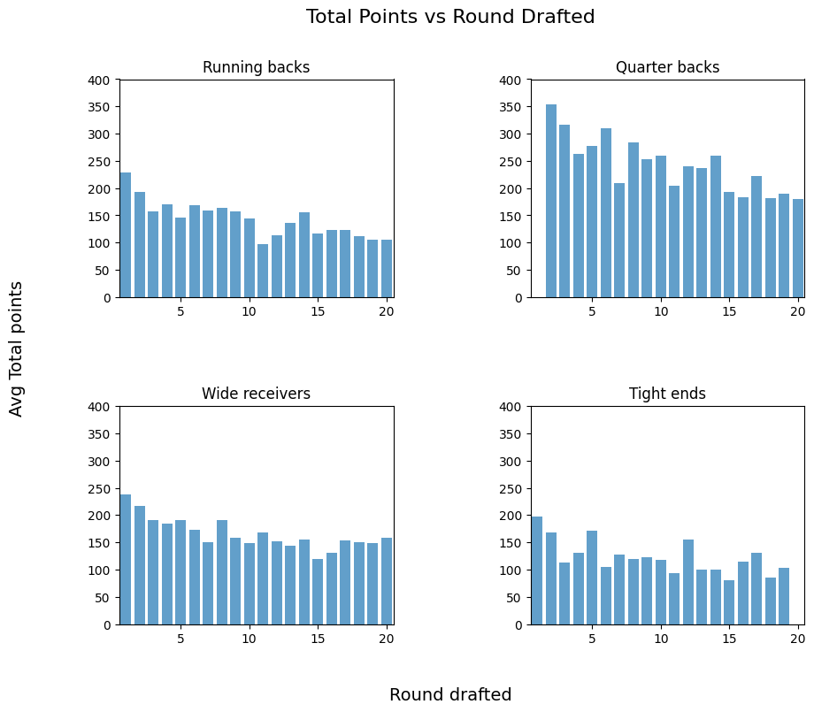

```python
# create a 2x2 plot of subplots
fig, axs = plt.subplots(2, 2, figsize=(10,8))

# so we can iterate through each position
all_position_dfs = [rb_dfs, qb_dfs, wr_dfs, te_dfs]
all_position_names = ['Running backs', 'Quarter backs', 'Wide receivers', 'Tight ends']

# Store the keys for the dictionary
all_position_abbr = ['RB', 'QB', 'WR', 'TE']

# Dictionary to store the average points per round for each position
average_points_dict = {abbr: [] for abbr in all_position_abbr}

# pos_i is position index, year_i is year index
for pos_i, ax in enumerate(axs.flat):
    total_points_per_round = np.zeros(20)
    counts_per_round = np.zeros(20)

    for year_i in range(4):
        # Filter data for rounds 1 to 20
        data = all_position_dfs[pos_i][year_i][all_position_dfs[pos_i][year_i]["RoundDrafted"] <= 20]

        # Sum total points and count occurrences for each round
        for round_num in range(1, 21):
            round_data = data[data["RoundDrafted"] == round_num]
            total_points_per_round[round_num-1] += round_data["TotalPoints"].sum()
            counts_per_round[round_num-1] += len(round_data)

    # Calculate the average total points for each round
    average_points_per_round_all = np.divide(total_points_per_round, counts_per_round, out=np.zeros_like(total_points_per_round), where=counts_per_round != 0)

    # Save the average points per round for the current position in the dictionary
    average_points_dict[all_position_abbr[pos_i]] = average_points_per_round_all.tolist()


    # Plot the average total points as a bar chart
    ax.bar(np.arange(1, 21), average_points_per_round_all, alpha=0.7)

    ax.set_title(all_position_names[pos_i])
    ax.set_xlim(0.5, 20.5)
    ax.set_ylim(0, 400)

# overall title
fig.suptitle('Total Points vs Round Drafted', fontsize=16)

# Add shared x and y labels
fig.text(0.5, 0.01, 'Round drafted', ha='center', va='center', fontsize=14)
fig.text(0.01, 0.5, 'Avg Total points', ha='center', va='center', rotation='vertical', fontsize=14)

# increase margins
plt.subplots_adjust(wspace=0.5, hspace=0.5)

plt.show()
```

Notice that we created a dictionary to store the average points per round for each position. This will come in handy to answer our first question.

We see that Quarterbacks generally score far more points than runningbacks, wide receivers, and tight ends, and generally scores over 250 fantasy points until round 10.

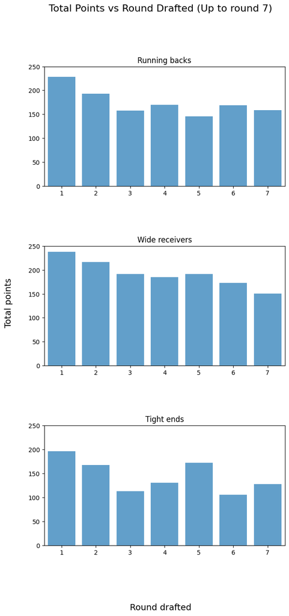

```python
# create a 2x2 plot of subplots
fig, axs = plt.subplots(3, 1, figsize=(7,14))

# so we can iterate through each position
all_position_dfs = [rb_dfs, wr_dfs, te_dfs]
all_position_names = ['Running backs', 'Wide receivers', 'Tight ends']

# pos_i is position index, year_i is year index
for pos_i, ax in enumerate(axs.flat):
    total_points_per_round = np.zeros(7)
    counts_per_round = np.zeros(7)

    for year_i in range(4):
        # Filter data for rounds 1 to 20
        data = all_position_dfs[pos_i][year_i][all_position_dfs[pos_i][year_i]["RoundDrafted"] <= 7]

        # Sum total points and count occurrences for each round
        for round_num in range(1, 8):
            round_data = data[data["RoundDrafted"] == round_num]
            total_points_per_round[round_num-1] += round_data["TotalPoints"].sum()
            counts_per_round[round_num-1] += len(round_data)

    # Calculate the average total points for each round
    average_points_per_round = np.divide(total_points_per_round, counts_per_round, out=np.zeros_like(total_points_per_round), where=counts_per_round != 0)

    # Plot the average total points as a bar chart
    ax.bar(np.arange(1, 8), average_points_per_round, alpha=0.7)

    ax.set_title(all_position_names[pos_i])
    ax.set_xlim(0.5, 7.5)
    ax.set_ylim(0, 250)

# overall title
fig.suptitle('Total Points vs Round Drafted (Up to round 7)', fontsize=16)

# Add shared x and y labels
fig.text(0.5, 0.01, 'Round drafted', ha='center', va='center', fontsize=14)
fig.text(0.01, 0.5, 'Total points', ha='center', va='center', rotation='vertical', fontsize=14)

# increase margins
plt.subplots_adjust(wspace=0.5, hspace=0.5)

plt.show()
```

For the smaller sample size, we can see that wide receivers tend to have a gradual decline in production, while runningbacks and tightends appear to have numbers that fluctuate more between each round.

### Standardize total points across positions

To answer questions like which position ought to be drafted first, we should standardize the datasets for each position. This is so we can make comparisions across positions. For example, we could compare how a good a QB is relative to other QBs with how good a WR is relative to other WRs.

Within each position, we could either standardize data within each year, or across all four years. To decide which option is better, we will make 4 plot of total points vs draft position - one for each position, where the years are distinguished by color. Thus, we can gain a better understanding of how similar trends are in different years as well as how many players within that position are drafted in that specific round.

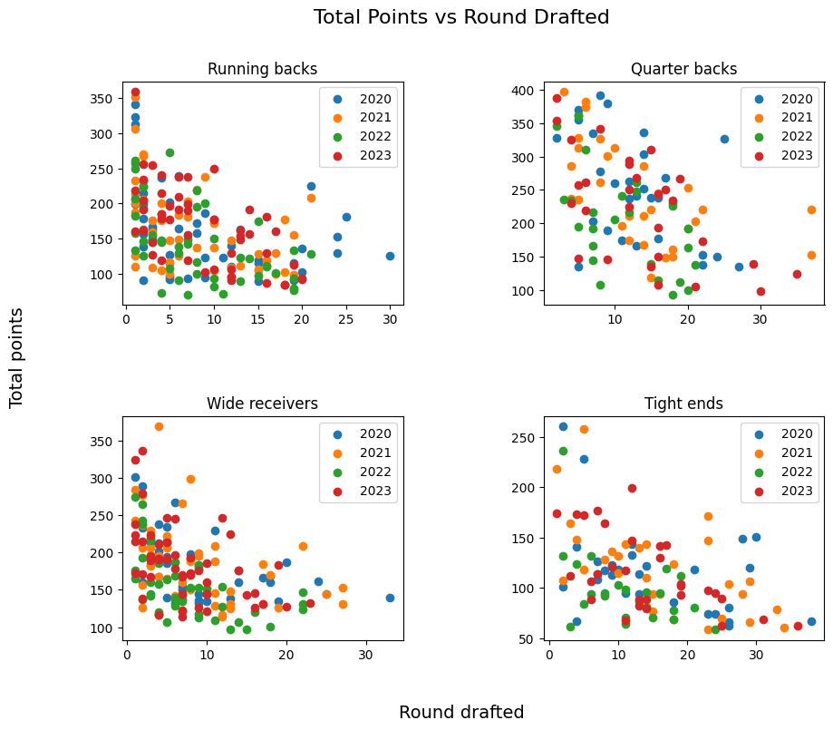

```python
# create a 2x2 plot of subplots
fig, axs = plt.subplots(2, 2, figsize=(10,8))

# so we can iterate through each position
all_position_dfs = [rb_dfs, qb_dfs, wr_dfs, te_dfs]
all_position_names = ['Running backs', 'Quarter backs', 'Wide receivers', 'Tight ends']

# pos_i is position index, year_i is year index
for pos_i, ax in enumerate(axs.flat):
    for year_i in range(4):
        ax.scatter(all_position_dfs[pos_i][year_i]["RoundDrafted"], all_position_dfs[pos_i][year_i]["TotalPoints"], label=years[year_i])
    ax.set_title(all_position_names[pos_i])
    ax.legend()

# overall title
fig.suptitle('Total Points vs Round Drafted', fontsize=16)

# Add shared x and y labels
fig.text(0.5, 0.01, 'Round drafted', ha='center', va='center', fontsize=14)
fig.text(0.01, 0.5, 'Total points', ha='center', va='center', rotation='vertical', fontsize=14)

# increase margins
plt.subplots_adjust(wspace=0.5, hspace=0.5)

plt.show()
```

The distributions are quite different among different positions. For RBs and WRs, there tend to be more players drafted early on that do not score many points. On the other hand, QBs and TEs don't have as many of these early-drafted low-scoring players. This supports our knowledge that people tend to draft RBs and WRs earlier on.

Without doing any calculations, it appears that the variance between the players performance was very large in the first couple of rounds, however it gradually decreased as the rounds increased. Between each year, we see that no one year looks significantly below or above the other years. Thus, we will probably standardize across all four years, instead of just within each year.

Below is a function to add a column that is the standardized total points (over all four years). It takes in a list of dataframes (for different years) for a position.

It returns the updated dataframe.

```python
def standardize_pos(pos_dfs):
    # take mean and std over all four years
    mean = np.array([pos_df['TotalPoints'].values for pos_df in pos_dfs]).mean()
    std = np.array([pos_df['TotalPoints'].values for pos_df in pos_dfs]).std()
    # for each year, add a column
    for i in range(len(pos_dfs)):
        pos_dfs[i]['TotalPointsStandardized'] = (pos_dfs[i]['TotalPoints'] - mean) / std
    return pos_dfs
```

We'll call our standardization function on all positions, which are stored in all_position_dfs.

The output is the RB 2023 dataframe, with a new column, TotalPointsStandardized.

```python
for i in range(len(all_position_dfs)):
    all_position_dfs[i] = standardize_pos(all_position_dfs[i])

rb_dfs[-1].head(10)
```

|  | PlayerName | PlayerId | Pos | Team | PassingYDS | PassingTD | PassingInt | RushingYDS | RushingTD | ReceivingRec | ... | ReceptionPercentage | RzTarget | RzTouch | RzG2G | Rank | TotalPoints | POS | AVG | RoundDrafted | TotalPointsStandardized |
| --- | --- | --- | --- | --- | --- | --- | --- | --- | --- | --- | --- | --- | --- | --- | --- | --- | --- | --- | --- | --- | --- |
| 0 | Christian McCaffrey | 2557997 | RB | SF | NaN | NaN | NaN | 1459.0 | 14.0 | 67.0 | ... | 81.0 | 16.0 | 75.0 | 39.0 | 1 | 359.80 | RB1 | 1.8 | 1.0 | 3.499232 |
| 1 | Travis Etienne | 2566157 | RB | JAX | NaN | NaN | NaN | 1008.0 | 11.0 | 58.0 | ... | 79.0 | 2.0 | 39.0 | 15.0 | 2 | 256.40 | RB8 | 23.5 | 2.0 | 1.704857 |
| 2 | Breece Hall | 2568030 | RB | NYJ | NaN | NaN | NaN | 994.0 | 5.0 | 76.0 | ... | 80.0 | 5.0 | 25.0 | 17.0 | 3 | 254.50 | RB9 | 34.0 | 3.0 | 1.671885 |
| 3 | Raheem Mostert | 2553728 | RB | MIA | NaN | NaN | NaN | 1012.0 | 18.0 | 25.0 | ... | 78.0 | 5.0 | 50.0 | 32.0 | 4 | 250.17 | RB35 | 114.8 | 10.0 | 1.596744 |
| 4 | Joe Mixon | 2557976 | RB | CIN | NaN | NaN | NaN | 1034.0 | 9.0 | 52.0 | ... | 81.0 | 13.0 | 67.0 | 42.0 | 5 | 241.00 | RB12 | 36.0 | 4.0 | 1.437610 |
| 5 | Rachaad White | 2568315 | RB | TB | NaN | NaN | NaN | 990.0 | 6.0 | 64.0 | ... | 91.0 | 8.0 | 45.0 | 23.0 | 6 | 238.50 | RB23 | 68.5 | 6.0 | 1.394226 |
| 6 | Kyren Williams | 2567862 | RB | LA | NaN | NaN | NaN | 1144.0 | 12.0 | 32.0 | ... | 67.0 | 12.0 | 55.0 | 34.0 | 7 | 238.50 | RB51 | 80.5 | 7.0 | 1.394226 |
| 7 | Derrick Henry | 2556075 | RB | TEN | 14.0 | 2.0 | NaN | 1167.0 | 12.0 | 28.0 | ... | 78.0 | 2.0 | 37.0 | 20.0 | 8 | 233.66 | RB7 | 20.8 | 2.0 | 1.310234 |
| 8 | Bijan Robinson | 2569558 | RB | ATL | NaN | NaN | NaN | 976.0 | 4.0 | 58.0 | ... | 67.0 | 10.0 | 27.0 | 18.0 | 9 | 218.07 | RB3 | 10.3 | 1.0 | 1.039689 |
| 9 | Jahmyr Gibbs | 2569747 | RB | DET | NaN | NaN | NaN | 945.0 | 10.0 | 52.0 | ... | 73.0 | 7.0 | 41.0 | 24.0 | 10 | 214.10 | RB14 | 37.5 | 4.0 | 0.970795 |

10 rows × 32 columns

We'll remake our Total points vs round drafted plot now, but using Standardized total points instead. We do this to ensure that the standardization actually seems to work, and no one position tends to have higher points than any other.

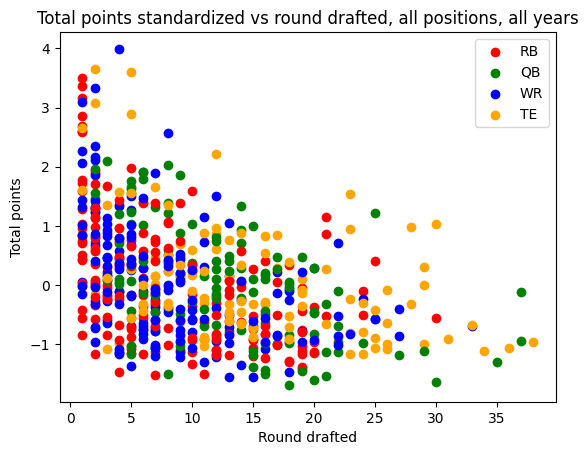

```python
plt.figure()
plt.title('Total points standardized vs round drafted, all positions, all years')
plt.xlabel('Round drafted')
plt.ylabel('Total points')

# for each year, plot data for all position
for i in range(4):
    plt.scatter(rb_dfs[i]["RoundDrafted"], rb_dfs[i]["TotalPointsStandardized"], color='red', label='RB')
    plt.scatter(qb_dfs[i]["RoundDrafted"], qb_dfs[i]["TotalPointsStandardized"], color='green', label='QB')
    plt.scatter(wr_dfs[i]["RoundDrafted"], wr_dfs[i]["TotalPointsStandardized"], color='blue', label='WR')
    plt.scatter(te_dfs[i]["RoundDrafted"], te_dfs[i]["TotalPointsStandardized"], color='orange', label='TE')

# the labels will keep repeating, but we only want the top four labels, so we make a custom legend
handles, labels = plt.gca().get_legend_handles_labels()
top_handles = handles[:4]
top_labels = labels[:4]
plt.legend(handles=top_handles, labels=top_labels)

plt.show()
```

Standardization has indeed successfully decreased the variation of points across different positions. The positions are now more ready to be compared to each other.

# Part 4: Model: Analysis, Hypothesis Testing, ML

### Q1: Does the Runningback dead zone exist?

The running back dead zone is defined as the space around rounds three to six, where there is a significant drop off in value for the runningbacks available. This is believed to occur because many NFL teams use a running back by committee approach, where 2 or 3 runningbacks will be used in a game. As a result, the points each of them score is expected to be lower.

Many draft strategies have appeared from this belief, such as zero-RB https://www.fantasylife.com/articles/best-ball/what-is-zero-rb-drafting-tips-from-a-pro, where the player does not believe this dead zone exists and only starts to draft RBs after round 4 or 5, and hero-RB https://www.espn.com/fantasy/football/story/_/id/38191251/fantasy-football-mock-draft-strategy-hero-rb-anchor-rb, where the player drafts multiple runningbacks within the first 3 rounds.

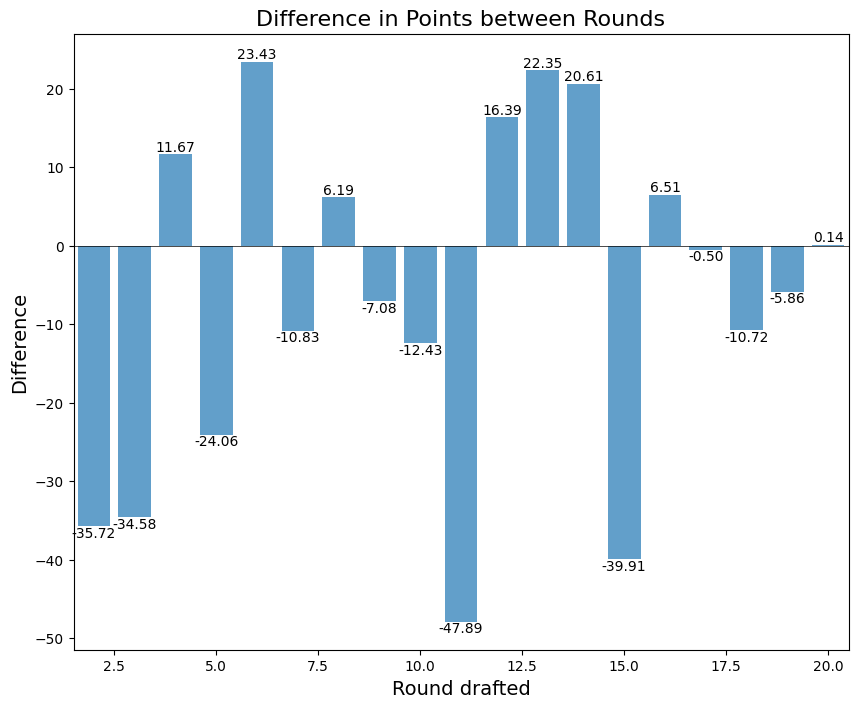

```python
average_points_rb = average_points_dict['RB']

# Calculate the differences between consecutive rounds
differences_rb = np.diff(average_points_rb)

# print(differences_rb)

fig, ax = plt.subplots(figsize=(10, 8))

# Plot the bars
bars = ax.bar(np.arange(2, 21), differences_rb, alpha=0.7)
ax.set_title('Difference in Points between Rounds', fontsize=16)
ax.set_xlabel('Round drafted', fontsize=14)
ax.set_ylabel('Difference', fontsize=14)
ax.set_xlim(1.5, 20.5)
ax.axhline(0, color='black', linewidth=0.5)


for bar in bars:
    yval = bar.get_height()
    ax.text(bar.get_x() + bar.get_width() / 2, yval, f'{yval:.2f}', ha='center', va='bottom' if yval >= 0 else 'top')

plt.show()
```

Each bar represents the change in points between two rounds. This graph does not appear to be linear, signifying there are instances where there could be a very steep change, or other instances where it stagnates. For example, the drop off in points from round 1 to round 2 is 35.72, while the drop off from round 2 to round 3 is 34.58. However, between round 3 and 4, the average points scored actually increases, and fluctutes. This shows that the drop off in runningback talent is extremely steep, meaning that there is only so many top tier players that by round 3 they are mostly gone, and the players onward are similar level in talent.

Taking the average points per round into context as well, we see that the points hover between 140 to 170 points between rounds 3 and 10. A runningback deadzone very much exists at that range.

```python
print("Avg pts per round:")
for i in range(10):
    print("Round {}: {:.2f}".format(i+1, average_points_rb[i]))
```

```
Avg pts per round:
Round 1: 228.35
Round 2: 192.63
Round 3: 158.05
Round 4: 169.72
Round 5: 145.66
Round 6: 169.09
Round 7: 158.26
Round 8: 164.45
Round 9: 157.37
Round 10: 144.94
```

#### Insights

Looking at both pieces of data, it does seem to contain a running back deadzone range. There is a steep decline in the production from top tier runningbacks after round two, leading the fluctuations in point differences in the subsequent rounds. However, we found that rather the deadzone range be from rounds 3 to 6, it actually extends up to round 10. This means two things. Firstly, if an owner is prioritizing drafting top tier runningbacks, then drafting one within the first two rounds is essential. However, if an owner misses this cutoff range, then it may be beneficial for him/her to wait on runningbacks until a little later within the deadzone, so that they can prioritize other positions while still receving a similar quality of runningback performance in the later rounds.

### Q2: Is drafting a quarterback or tight end within the first 3 rounds worth the investment?

Another pattern many managers employ is holding off on drafting a quarterback in the early rounds, believing that there would be significant amounts of high performing quarterbacks in later rounds https://campus2canton.com/breaking-down-the-late-round-qb-cff-draft-strategy/. On the other hand, managers race to draft a top 3 tight end, believing they have a significant drop off as well https://www.draftsharks.com/article/fantasy-football-draft-preview-tight-ends.

We create two hypothesis tests to answer this question.

Test 1

- H<sub>0</sub>: The top 3 quarterbacks drafted do not substantially outproduce quarterbacks drafted outside of the top 3
- H<sub>1</sub>: The top 3 quarterbacks drafted do substantially outproduce quarterbacks drafted outside of the top 3

Test 2

- H<sub>0</sub>: The top 3 tight ends drafted do not substantially outproduce tight ends drafted outside of the top 3
- H<sub>1</sub>: The top 3 tight ends drafted do substantially outproduce tight ends drafted outside of the top 3

We can explore both of these hypothesis by creating two categories for each position:

**Outside Top 3 Drafted:** QBs and TEs drafted outside the top 3.

We can then calculate the **mean** and **standard deviation** of our two samples and test our hypotheses.

```python
top3_means = []
outside_top3_means = []

for df in qb_dfs:
    # Get the mean fantasy points for top 3 and outside top 3
    top3_mean = df[df['Rank'] <= 3]['TotalPoints'].mean()
    outside_top3_mean = df[df['Rank'] > 3]['TotalPoints'].mean()

    # Append the means to the respective lists
    top3_means.append(top3_mean)
    outside_top3_means.append(outside_top3_mean)

# Convert lists to pandas Series for easier statistical analysis
top3_series = pd.Series(top3_means, index=[2020, 2021, 2022, 2023])
outside_top3_series = pd.Series(outside_top3_means, index=[2020, 2021, 2022, 2023])

# Perform normality test
top3_normality = stats.shapiro(top3_series)
outside_top3_normality = stats.shapiro(outside_top3_series)

if top3_normality.pvalue > 0.05 and outside_top3_normality.pvalue > 0.05:
    t_test_result = stats.ttest_ind(top3_series, outside_top3_series)
else:
    t_test_result = stats.mannwhitneyu(top3_series, outside_top3_series)

# print(top3_means, outside_top3_means)

print("Top 3 QBs Mean Fantasy Points by Year:")
print(top3_series)

print("Outside Top 3 QBs Mean Fantasy Points by Year:")
print(outside_top3_series)

print("T-Test Result:", t_test_result)
qb_means = (top3_means, outside_top3_means)
```

```
Top 3 QBs Mean Fantasy Points by Year:
2020    381.930000
2021    384.683333
2022    351.880000
2023    361.013333
dtype: float64
Outside Top 3 QBs Mean Fantasy Points by Year:
2020    238.504828
2021    227.823448
2022    183.838966
2023    207.921034
dtype: float64
T-Test Result: TtestResult(statistic=10.754499830659256, pvalue=3.820044061247116e-05, df=6.0)
```

```python
top3_means = []
outside_top3_means = []

for df in te_dfs:
    # Get the mean fantasy points for top 3 and outside top 3
    top3_mean = df[df['Rank'] <= 3]['TotalPoints'].mean()
    outside_top3_mean = df[df['Rank'] > 3]['TotalPoints'].mean()

    # Append the means to the respective lists
    top3_means.append(top3_mean)
    outside_top3_means.append(outside_top3_mean)

# Convert lists to pandas Series for easier statistical analysis
top3_series = pd.Series(top3_means, index=[2020, 2021, 2022, 2023])
outside_top3_series = pd.Series(outside_top3_means, index=[2020, 2021, 2022, 2023])

# Perform normality test
top3_normality = stats.shapiro(top3_series)
outside_top3_normality = stats.shapiro(outside_top3_series)

if top3_normality.pvalue > 0.05 and outside_top3_normality.pvalue > 0.05:
    t_test_result = stats.ttest_ind(top3_series, outside_top3_series)
else:
    t_test_result = stats.mannwhitneyu(top3_series, outside_top3_series)

# print(top3_means, outside_top3_means)

print("Top 3 TEs Mean Fantasy Points by Year:")
print(top3_series)

print("Outside Top 3 TEs Mean Fantasy Points by Year:")
print(outside_top3_series)

print("T-Test Result:", t_test_result)
te_means = (top3_means, outside_top3_means)
```

```
Top 3 TEs Mean Fantasy Points by Year:
2020    213.120000
2021    215.866667
2022    166.266667
2023    183.600000
dtype: float64
Outside Top 3 TEs Mean Fantasy Points by Year:
2020    100.821379
2021    104.522069
2022     82.070345
2023    104.824828
dtype: float64
T-Test Result: MannwhitneyuResult(statistic=16.0, pvalue=0.02857142857142857)
```

### Interpertation

**QBs**

From the result of our T-test, we can observe a t-value of 10.75. This indicates that there is a significant difference between the means of the top 3 drafted QB's and the rest of the dataset. Alternatively, the difference would be over 10 times the standard error. This finding is augmented by the low p-value (0.0000382).

To conclude, We are able to reject the Null Hypothesis, H<sub>0</sub> (The top 3 quarterbacks drafted do not substantially outproduce quarterbacks drafted outside of the top 3) in support for the alternative hypothesis H<sub>1</sub> (The top 3 quarterbacks drafted do substantially outproduce quarterbacks drafted outside of the top 3)

**TEs**

The Mann-Whitney U test was used instead of the t-test due to the non-normality of the data. The p-value of 0.02857 < 0.05, indicating that we again, reject the null hypothesis, H<sub>0</sub> (The top 3 tight ends drafted do not substantially outproduce tight ends drafted outside of the top 3) in favor of the alternative hypothesis H<sub>1</sub> (The top 3 tight ends drafted do substantially outproduce tight ends drafted outside of the top 3)

Additonally, we can calculate the difference between the means to determine which one should be valued more.

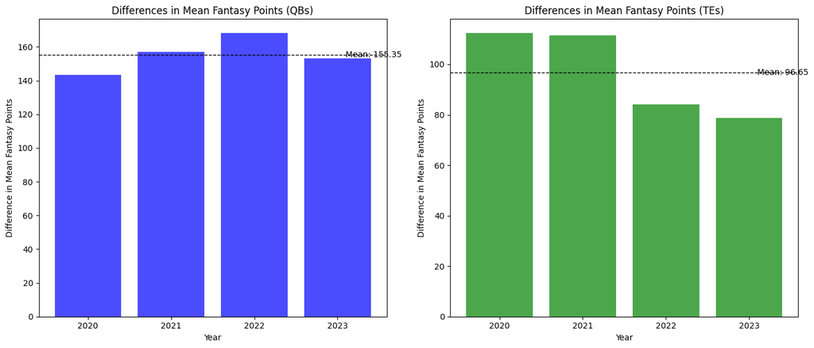

```
Mean Difference for QBs: 155.35459770114943
Mean Difference for TEs: 96.65367816091955
```

```python
top3qbs, outsidetop3qbs = qb_means
top3te, outsidetop3te = te_means

# Calculate the differences for QBs
qb_differences = [top - outside for top, outside in zip(top3qbs, outsidetop3qbs)]
qb_mean_difference = np.mean(qb_differences)

# Calculate the differences for TEs
te_differences = [top - outside for top, outside in zip(top3te, outsidetop3te)]
te_mean_difference = np.mean(te_differences)

# Years corresponding to the data
years = [2020, 2021, 2022, 2023]

# Plotting the bar plots
plt.figure(figsize=(14, 6))

# Bar plot for QB differences
plt.subplot(1, 2, 1)
plt.bar(years, qb_differences, color='b', alpha=0.7)
plt.xlabel('Year')
plt.ylabel('Difference in Mean Fantasy Points')
plt.title('Differences in Mean Fantasy Points (QBs)')
plt.axhline(qb_mean_difference, color='k', linestyle='dashed', linewidth=1)
plt.text(years[-1] + 0.1, qb_mean_difference, f'Mean: {qb_mean_difference:.2f}', va='center')
plt.xticks(years)

# Bar plot for TE differences
plt.subplot(1, 2, 2)
plt.bar(years, te_differences, color='g', alpha=0.7)
plt.xlabel('Year')
plt.ylabel('Difference in Mean Fantasy Points')
plt.title('Differences in Mean Fantasy Points (TEs)')
plt.axhline(te_mean_difference, color='k', linestyle='dashed', linewidth=1)
plt.text(years[-1] + 0.1, te_mean_difference, f'Mean: {te_mean_difference:.2f}', va='center')
plt.xticks(years)

# Show plot
plt.tight_layout()
plt.show()

# Print the mean of the differences
print("Mean Difference for QBs:", qb_mean_difference)
print("Mean Difference for TEs:", te_mean_difference)
```

### Insights (cont.)

Now, we can see that quarterbacks (QBs) show a greater mean difference in points compared to tight ends (TEs) when comparing the top 3 players to those ranked outside the top 3. This indicates that the top-performing QBs consistently provide a higher level of performance relative to their lower-ranked counterparts than the top TEs do.

Therefore, to maximize gain, drafting a top quarterback earlier than a TE in the draft is a more strategic move.

### Q3: Which position has the greatest probability of producing breakout players?

Every fantasy manager wants to find a breakout player, a player that ends up significantly outperforming their expected performance. This player can be defined as the following, players who were unknown to the league or players who were once very productive but has since been underperforming. We will examine the performance of each position relative to the performance of other players in that position to determine if they can be considered a breakout player or sleeper pick. For more information on sleepers and current sleeper picks for this year, see [https://www.draftsharks.com/article/fantasy-football-sleepers]

First, let us use the standardized dataframes.

We first create the dataframe to store just the projected rankings and the season performance standardized.

```python
# Initialize lists to store dataframes with selected columns
rb_projected_and_season = []
wr_projected_and_season = []
te_projected_and_season = []
qb_projected_and_season = []

# Function to filter dataframes and store them in a new list
def filter_columns(original_dfs):
    filtered_dfs = []
    for df in original_dfs:
        selected_columns = df[["POS", "TotalPointsStandardized"]]
        filtered_dfs.append(selected_columns)
    return filtered_dfs

# Filter the dataframes and store them in the new lists
rb_projected_and_season = filter_columns(rb_dfs)
wr_projected_and_season = filter_columns(wr_dfs)
te_projected_and_season = filter_columns(te_dfs)
qb_projected_and_season = filter_columns(qb_dfs)
```

Let's see our results!

```python
# Display top 5 performances based on standardized points in the 2023 season.
rb_projected_and_season[-1].head()
```

|  | POS | TotalPointsStandardized |
| --- | --- | --- |
| 0 | RB1 | 3.499232 |
| 1 | RB8 | 1.704857 |
| 2 | RB9 | 1.671885 |
| 3 | RB35 | 1.596744 |
| 4 | RB12 | 1.437610 |

```python
# Display top 5 performances based on standardized points in the 2020 season
wr_projected_and_season[0].head()
```

|  | POS | TotalPointsStandardized |
| --- | --- | --- |
| 0 | WR2 | 2.607273 |
| 1 | WR3 | 2.356256 |
| 2 | WR27 | 1.911363 |
| 3 | WR17 | 1.327696 |
| 4 | WR22 | 1.260350 |

```python
# Display top 5 performances based on standardized points in the 2021 season
qb_projected_and_season[1].head()
```

|  | POS | TotalPointsStandardized |
| --- | --- | --- |
| 0 | QB2 | 2.095068 |
| 1 | QB8 | 1.904013 |
| 2 | QB9 | 1.795761 |
| 3 | NaN | 1.564732 |
| 4 | QB5 | 1.236252 |

```python
# Display top 5 performances based on standardized points in the 2022 season
te_projected_and_season[2].head()
```

|  | POS | TotalPointsStandardized |
| --- | --- | --- |
| 0 | TE1 | 3.072237 |
| 1 | TE2 | 0.582055 |
| 2 | TE7 | 0.582055 |
| 3 | TE4 | 0.383891 |
| 4 | TE22 | 0.288390 |

Now let's determine the percentiles for the position ranking before the season and then standardized points after the season. We will use the scipy.stats library for that. Let us also create a function for that. We also need to handle the case where there are NaN values in POS, we can just use a large number for those cases.

```python
from scipy.stats import percentileofscore
```

```python
rb_projected_and_season_percentiles = []
wr_projected_and_season_percentiles = []
te_projected_and_season_percentiles = []
qb_projected_and_season_percentiles = []
```

Let's now find the percentiles.

```python
def calculate_percentiles(dfs):
    filtered_dfs = []
    for df in dfs:
        columns = df[["POS", "TotalPointsStandardized"]].copy()

        # Replace NaN values in 'POS' with a high number
        columns.fillna({'POS' : 99999}, inplace=True)
        columns['POS'] = columns['POS'].astype(str)

        # Calculate rank for TotalPointsStandardized
        columns['PositionRank'] = columns['TotalPointsStandardized'].rank(ascending=False)

        # Calculate percentiles for TotalPointsStandardized
        columns['TotalPointsPercentile'] = columns['TotalPointsStandardized'].apply(
            lambda x: percentileofscore(columns['TotalPointsStandardized'], x)
        )

        # Calculate percentiles for POS. We use 100 - percentile to signify
        # that a lower number means the player is ranked higher, and thus in a higher percentile.
        columns['POSPercentile'] = columns['POS'].apply(
            lambda x: 100 - percentileofscore(columns['POS'], x)
        )

        filtered_dfs.append(columns)
    return filtered_dfs

rb_projected_and_season_percentiles = calculate_percentiles(rb_dfs)
wr_projected_and_season_percentiles = calculate_percentiles(wr_dfs)
te_projected_and_season_percentiles = calculate_percentiles(te_dfs)
qb_projected_and_season_percentiles = calculate_percentiles(qb_dfs)
```

Take a look at our results.

```python
# Display top 5 RB performances based on standardized points in the 2023 season.
rb_projected_and_season_percentiles[-1].head()
```

|  | POS | TotalPointsStandardized | PositionRank | TotalPointsPercentile | POSPercentile |
| --- | --- | --- | --- | --- | --- |
| 0 | RB1 | 3.499232 | 1.0 | 100.0 | 98.0 |
| 1 | RB8 | 1.704857 | 2.0 | 98.0 | 2.0 |
| 2 | RB9 | 1.671885 | 3.0 | 96.0 | 0.0 |
| 3 | RB35 | 1.596744 | 4.0 | 94.0 | 52.0 |
| 4 | RB12 | 1.437610 | 5.0 | 92.0 | 92.0 |

```python
# Display top 5 WR performances based on standardized points in the 2022 season.
wr_projected_and_season_percentiles[2].head()
```

|  | POS | TotalPointsStandardized | PositionRank | TotalPointsPercentile | POSPercentile |
| --- | --- | --- | --- | --- | --- |
| 0 | WR2 | 2.063606 | 1.0 | 100.0 | 68.0 |
| 1 | WR8 | 1.862384 | 2.0 | 98.0 | 10.0 |
| 2 | WR4 | 1.423614 | 3.0 | 96.0 | 40.0 |
| 3 | WR5 | 1.325656 | 4.0 | 94.0 | 26.0 |
| 4 | WR11 | 0.884845 | 5.0 | 92.0 | 84.0 |

```python
# Display top 5 QB performances based on standardized points in the 2021 season.
qb_projected_and_season_percentiles[1].head()
```

|  | POS | TotalPointsStandardized | PositionRank | TotalPointsPercentile | POSPercentile |
| --- | --- | --- | --- | --- | --- |
| 0 | QB2 | 2.095068 | 1.0 | 100.000 | 65.6250 |
| 1 | QB8 | 1.904013 | 2.0 | 96.875 | 3.1250 |
| 2 | QB9 | 1.795761 | 3.0 | 93.750 | 0.0000 |
| 3 | 99999 | 1.564732 | 4.0 | 90.625 | 95.3125 |
| 4 | QB5 | 1.236252 | 5.0 | 87.500 | 18.7500 |

```python
# Display top 5 TE performances based on standardized points in the 2020 season.
te_projected_and_season_percentiles[0].head()
```

|  | POS | TotalPointsStandardized | PositionRank | TotalPointsPercentile | POSPercentile |
| --- | --- | --- | --- | --- | --- |
| 0 | TE1 | 3.656225 | 1.0 | 100.000 | 87.500 |
| 1 | TE5 | 2.897948 | 2.0 | 96.875 | 25.000 |
| 2 | TE68 | 1.038071 | 3.0 | 93.750 | 12.500 |
| 3 | TE59 | 0.986023 | 4.0 | 90.625 | 21.875 |
| 4 | TE14 | 0.868557 | 5.0 | 87.500 | 71.875 |

```python
top_70_percentile = 70
percentile_difference = 20

def calculate_breakout_number(dfs, breakout_count):
    for df in dfs:
        for index, row in df.iterrows():
            if row['TotalPointsPercentile'] >= top_70_percentile and (row['TotalPointsPercentile'] - row['POSPercentile']) >= 20:
                breakout_count += 1
    return breakout_count
```

Let's find the numbers now.

```python
breakout_players_rb = calculate_breakout_number(rb_projected_and_season_percentiles, 0)
breakout_players_wr = calculate_breakout_number(wr_projected_and_season_percentiles, 0)
breakout_players_qb = calculate_breakout_number(qb_projected_and_season_percentiles, 0)
breakout_players_te = calculate_breakout_number(te_projected_and_season_percentiles, 0)

# Print the results
print(f"Breakout Running Backs: {breakout_players_rb}")
print(f"Breakout Wide Receivers: {breakout_players_wr}")
print(f"Breakout Quarterbacks: {breakout_players_qb}")
print(f"Breakout Tight Ends: {breakout_players_te}")
```

```
Breakout Running Backs: 40
Breakout Wide Receivers: 41
Breakout Quarterbacks: 22
Breakout Tight Ends: 22
```

That was the total number of breakout players found. Let's find the average amount per season by dividng by 4.

```python
print(f"On average {breakout_players_rb / 4} runningbacks broke out in a season.")
print(f"On average {breakout_players_wr / 4} wide receivers broke out in a season.")
print(f"On average {breakout_players_qb / 4} quarterbacks broke out in a season.")
print(f"On average {breakout_players_te / 4} tight ends broke out in a season.")
```

```
On average 10.0 runningbacks broke out in a season.
On average 10.25 wide receivers broke out in a season.
On average 5.5 quarterbacks broke out in a season.
On average 5.5 tight ends broke out in a season.
```

#### Insights

This showcases that contrary to the belief that runningbacks in the later rounds could not be classified as productive, there is still a plethora of talent available. Rather, the data suggests that quarterbacks and tightends may be less volatile, and generally fit more closely to their previous rankings. Consequently, a manager may want to wait until the middle rounds (4-7) to draft a quarterback or tightend, since the chances of a breakout are lower. In order to maximize the chances of drafting a breakout player, managers should target runningbacks and receviers in the later rounds (9+).

### Q4: Can we predict how well a quarterback will do based on their volume metrics?

Our first three questions attempted to answer some of the biggest questions regarding which position of players to target, but now that we have decided on a specific position, what players are best to draft for that position? Thus we are attempting to ask how does the amount of attempts to score points (volume) impact fantasy success for Quarterbacks.

Total points is calculated off of some metrics, such as yards, touchdowns, and receptions, but disregards other metrics, such as touches, targets, and red zone statistics. We will see if these unused metrics can predict what percentile a player will end up being relative to all other players of their position. You can read more on how fantasy points are calculated here https://fantasydata.com/api/fantasy-scoring-system/nfl.

Focusing on quarterbacks, We will attempt to fit a regression line to predict the total points generated by the player, and analyze the mean squared error, along with with the weights to determine how well it did.

We will be using the following statistics as our weights: Touch Carries, Touch Receptions, Touches, Targets Receptions, Reception Percentage, Red Zone Target, Red Zone Touches, Red Zone Goal to Goal, and Total Points.

The Redzone is classified as the area of the field between the 20 yard line and the endzone, while ReadZoneG2G is between the 10 yard line and the endzone.

For quarterbacks more specifically, since they don't often catch the ball, only Touches, Redzone Touches, and Red Zone Goal to Goal Touches are significant. We will attempt to see how accurate they are in determining a players fantasy performance.

Due to data being missing at random (MAR), and many players not getting to play each season, we will fill the missing data in as 0's, add only the touch statistics, in addition to the regular point calculation.

```python
def merge_and_clean(dataframe_list):
    """
    Merges a list of DataFrames into a single DataFrame and drops columns unrelated to
    the calculation of fantasy football points, except for columns related to touches.

    Parameters:
    dataframe_list (list of pd.DataFrame): List of DataFrames to merge and filter

    Returns:
    pd.DataFrame: A single merged and filtered DataFrame
    """
    # Concatenate the list of DataFrames
    concatenated_df = pd.concat(dataframe_list, ignore_index=True)

    # Define columns to keep
    columns_to_keep = [
        'PassingYDS', 'PassingTD', 'PassingInt',
        'RushingYDS', 'RushingTD',
        'ReceivingRec', 'ReceivingYDS', 'ReceivingTD',
        'RetTD', 'FumTD', '2PT', 'Fum',
        'FanPtsAgainst-pts', 'TouchCarries', 'TouchReceptions', 'Touches',
        'TargetsReceptions', 'Targets', 'ReceptionPercentage',
        'RzTarget', 'RzTouch', 'RzG2G', 'TotalPoints'
    ]

    # Filter the DataFrame to keep only the necessary columns
    filtered_df = concatenated_df[columns_to_keep]
    filtered_df = filtered_df.fillna(0)

    return filtered_df
```

```python
t_qb_dfs = qb_dfs.copy()
t_qb_dfs = merge_and_clean(t_qb_dfs[:3])
```

```python
from sklearn.model_selection import train_test_split
from sklearn.linear_model import LinearRegression
from sklearn.metrics import mean_squared_error
# We'll test with a regression line to see how it fits the data.
```

```python
X = t_qb_dfs.drop(columns=['TotalPoints'])
y = t_qb_dfs['TotalPoints']

X_train, X_val, y_train, y_val = train_test_split(X, y, test_size=0.2, random_state=42)

# Initialize and train the model
model = LinearRegression()
model.fit(X_train, y_train)

# Make predictions on the validation set
y_pred = model.predict(X_val)

# Calculate and print the Mean Squared Error
mse = mean_squared_error(y_val, y_pred)
print(f'Mean Squared Error: {mse}')

# Print the weights (coefficients)
weights = model.coef_
intercept = model.intercept_

print('Weights:')

# Print the weights along with their corresponding feature names
for feature, weight in sorted(zip(X.columns, weights), key=lambda x: x[1], reverse=True):
    print(f'{feature}: {weight}')

print('Intercept:', intercept)


# print(y_val[:5])
# print(y_pred[:5])
```

```
Mean Squared Error: 5.110956491534379
Weights:
RushingTD: 5.623590546432133
PassingTD: 4.025102411004284
2PT: 1.9139546126111042
ReceivingTD: 0.9572764621788773
TargetsReceptions: 0.8506795888016528
TouchReceptions: 0.850679588801652
ReceivingRec: 0.8506795888016474
Touches: 0.39757823786272933
RzTouch: 0.308296532512347
RushingYDS: 0.10368497210562243
PassingYDS: 0.03914679445213114
ReceivingYDS: 0.030760861798178562
RzG2G: 0.014217275589441386
RetTD: 1.1102230246251565e-15
FumTD: 2.220446049250313e-16
ReceptionPercentage: -0.003585684126192031
FanPtsAgainst-pts: -0.06978701370262158
RzTarget: -0.36145031980687875
TouchCarries: -0.45310135093891973
Targets: -0.7850025830821221
Fum: -1.6737082466356523
PassingInt: -1.866946533268472
Intercept: 3.001660936673261
```

We can observe an interesting pattern in the weights and intercept of the linear regression model. It seems like an intercept of 3 was chosen, with weights being similar to actual fantasy football point calculation. One interesting weight allocation can be found with the touches, placing itself below ReceivingRecs and above RushingYDS. We were able to train the linear regression model to have a MSE of ~5. Can we do better?

This time, We will train a neural network on data up to 2022. The features will be the unused metrics listed. We will then try to predict data from 2023, with our model. We will compare our predictions to the real 2023 data to see how well our predictions match reality. If our predictions match our test data well, then perhaps these unused statistics could be a useful measure of how well a player will do. If our predictions don't predict known data well, then we probably ought to stick with the current statistics used to calculate total points. We will be using the relu activation function, and the adam optimizer for gradient descent

```python
import tensorflow as tf
from tensorflow.keras.models import Sequential
from tensorflow.keras.layers import Dense
from tensorflow.keras.optimizers import Adam
from tensorflow.keras.losses import MeanSquaredError
```

```python
# supress warnings
import warnings
warnings.filterwarnings('ignore', category=DeprecationWarning)
warnings.filterwarnings('ignore', category=FutureWarning)

tf.get_logger().setLevel('ERROR')
```

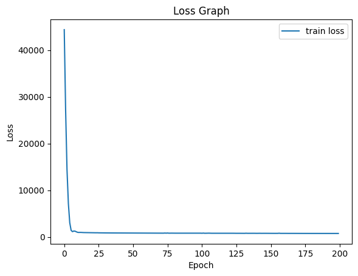

```python
train_dfs = qb_dfs.copy()[:3]
test_dfs = qb_dfs.copy()[3:]

# Clean and merge the datasets
train_df = merge_and_clean(train_dfs)
test_df = merge_and_clean(test_dfs)

# Split data into features and target
X_train = train_df.drop(columns=['TotalPoints'])
y_train = train_df['TotalPoints']
X_test = test_df.drop(columns=['TotalPoints'])
y_test = test_df['TotalPoints']


# Define the neural network model
model = Sequential([
    Dense(64, activation='relu', input_shape=(X_train.shape[1],)),
    Dense(32, activation='relu'),
    Dense(16, activation='relu'),
    Dense(1)  # Output layer
])

# Compile the model
model.compile(optimizer=Adam(learning_rate=0.0001), loss=MeanSquaredError())

# Train the model and store the training history
history = model.fit(X_train, y_train, validation_data=(X_test, y_test), epochs=200, batch_size=16, verbose=0)

# Plot the loss graph
plt.plot(history.history['loss'], label='train loss')
plt.xlabel('Epoch')
plt.ylabel('Loss')
plt.title('Loss Graph')
plt.legend()
plt.show()
```

### Let's get a closer look..

```python
# Evaluate the model on the test dataset
test_loss = model.evaluate(X_test, y_test)
# Make predictions

y_pred = model.predict(X_test)
print(f'Test Loss: {test_loss}')

# Print first few predictions
print(y_pred[:5])
print(y_test[:5])
```

```
1/1 ━━━━━━━━━━━━━━━━━━━━ 0s 63ms/step - loss: 706.8223
1/1 ━━━━━━━━━━━━━━━━━━━━ 0s 63ms/step - loss: 706.8223
1/1 ━━━━━━━━━━━━━━━━━━━━ 0s 32ms/step
Test Loss: 706.822265625
[[334.92975]
 [319.7644 ]
 [311.04132]
 [342.86276]
 [288.57953]]
0    387.51
1    354.22
2    341.31
3    325.59
4    309.86
Name: TotalPoints, dtype: float64
```

It seems like we are getting worse preformance with the neuralnetwork. In order to test the two models, we will be using the same splitting method in order to normalize their preformances and compare.

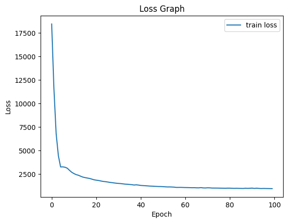

```python
# Old test-train split
X_train, X_val, y_train, y_val = train_test_split(X, y, test_size=0.2, random_state=42)


# Define the neural network model
model = Sequential([
    Dense(64, activation='relu', input_shape=(X_train.shape[1],)),
    Dense(32, activation='relu'),
    Dense(16, activation='relu'),
    Dense(1)  # Output layer
])

# Compile the model
model.compile(optimizer=Adam(learning_rate=0.0001), loss=MeanSquaredError())

# Train the model and store the training history
history = model.fit(X_train, y_train, validation_data=(X_val, y_val), epochs=100, batch_size=18, verbose=0)

# Plot the loss graph
plt.plot(history.history['loss'], label='train loss')
plt.xlabel('Epoch')
plt.ylabel('Loss')
plt.title('Loss Graph')
plt.legend()
plt.show()
```

### Again, A closer look..

```python
# Evaluate the model on the test dataset
test_loss = model.evaluate(X_test, y_test)
# Make predictions

y_pred = model.predict(X_test)
print(f'Test Loss: {test_loss}')

# Print first few predictions
print(y_pred[:5])
print(y_test[:5])
```

```
1/1 ━━━━━━━━━━━━━━━━━━━━ 0s 10ms/step - loss: 677.1705
1/1 ━━━━━━━━━━━━━━━━━━━━ 0s 10ms/step - loss: 677.1705
1/1 ━━━━━━━━━━━━━━━━━━━━ 0s 24ms/step
Test Loss: 677.1704711914062
[[334.83905]
 [326.32663]
 [306.84564]
 [337.21365]
 [283.31985]]
0    387.51
1    354.22
2    341.31
3    325.59
4    309.86
Name: TotalPoints, dtype: float64
```

### Interpretation

Now, we can conclude that our neural network preforms worse than our fitted linear regresson line. This can be due to overfitting, where the neural network captures too much noise from the training data that do not generalize well to new, unseen data. The linear regression model, being simpler, may generalize better if the underlying relationship between the features and the target variable is approximately linear. Additionally, there may have not been enough data to allow the neural network to preform at optimal efficency.

#### What does this mean for fantasy?

Our results corroborate with this article on how "volume is king", explaining how for various positions that opportunties to score will lead to more fantasy points.

https://www.espn.com/fantasy/football/story/_/id/38069858/fantasy-football-statistics-targets-trends

For the manager, it would be ideal to draft a quarterback that they anticipate would drive down the field more and get into the redzone, so that they could have more opportunities to score touchdowns and fantasy points.

# Part 5: Interpretation / Insight

Based on the 4 Questions that we asked, these are our following insights and answers.

1. **Does the runningback dead zone exist?**

The runningback dead zone does exist between rounds 3-10. The draft strategy accordingly should be users should target runningbacks in rounds 1 and 2, but hold off on drafting them until rounds 7-10 to still reap similar production to RBs selected earlier in the deadzone.

4. **Can we predict how well a quarterback will do based on their volume metrics?**